# Laminar Flow

Jack Hanlon, Forest Stothart

Spring 2021

The objective of this Laboratory Demonstration was to visualize Laminar Flow to our classmates, and to explain the effects of Reynolds number on the flow. It was conducted via three experiments: Osborne-Reynolds Apparatus, the Couette Cell and a punctured water-filled Balloon experiment.

### Osborne-Reynolds Apparatus

In this experiment a tank filled with marbles (to help create laminar flow) and water has a central pipe that leaks a steady flow rate based on a valve opening. Dye is then injected into this flow to help visualize the flow type. The flow rate is then varied between Laminar flow, Laminar-Turbulent transitional flow, and then fully Turbulent flow. Reynolds number is then calculated from the measurements taken of flow rate, to show the Reynolds number ranges of the flow in a pipe with STP water. The Laminar flow was shown to have a single dye streak through the pipe. The Laminar-Turbulent transitional flow was Laminar at the beginning of the pipe and became turbulent further down the pipe, with the dye moving erratically in the fluid. Lastly, the Turbulent flow dye was erratic as soon as the dye entered the pipe.

#### Equipment

- Hydraulics Bench
- Osborne Reynolds Apparatus
- Ink/Dye (Orange/Black)
- Bucket
- Cell phone stopwatch

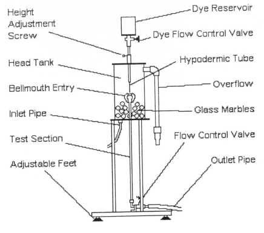

#### Procedure:

Firstly, the Osborne-Reynolds Apparatus is placed on a table and filled with sufficient water using a pneumatic pump. The inflow control valve is left open to allow minimal overflow control of the tank. The pump was ran until the air bubbles were removed. Next the dye is added to the top inflow pipette and the outflow valve is opened to start a flow from the tank through the pipe and into the bucket. Dye is then slowly released into the system,flowing through the pipe, allowing for better visualization of the type of flow. The outflow valve is then opened and closed to measure Laminar and Turbulent flow. This was done by using a beaker and a stopwatch to measure the water that is flowing through the pipe/sec as an average of multiple attempts for each flow type.

#### Discussion:

The flow rate was tuned to produce Laminar flow, as shown in the first image, an orange dye streak outlines how the flow travels in a straight line. Orange dye happened to be difficult to view because over time it became thinner in the stream, so the dye colour was switched to black which became much clearer for the rest of the experiment. It was noted that Laminar flow was a very unstable flow as any perturbations to the table the apparatus was on would immediately turn the flow to turbulent (This occurred from actions such as leaning on the table or writing down calculations ). After looking at Laminar flow, the flow rate was increased until the flow was transitional and back to show the process of Laminar flow becoming Turbulent. It was noted that the turbulence appears first further down the stream in the pipe and then works its way up back until the entire pipe is turbulent. Therefore, there is a flow rate in which some of the flow is Laminar as it passes out of the tank and becomes turbulent as it travels through the pipe. Lastly, the turbulent flow was observed past a Reynolds number of 4000 and it was turbulent at a fully open outflow valve.

##### Hints:

1. Make sure to check the outflow bucket often as it is of finite size, the lab floor eventually pays the price.
2. When calculating turbulent flow rate it is better to leave the pump on, otherwise the tank drains too quickly and it is hard to take a measurement.
3. The dye injection pipette can get air bubbles trapped in it that prevent the flow. To counteract this lift the pipette out of the tank and shake it to allow the air bubbles to escape, this should start the dye flow. (Be careful to keep the end over the hole into the tank otherwise ink will get spilled on the apparatus).

#### Results:

The Reynolds number was calculated for several different flow rates to characterize them. Using the equation:

$$Re = \frac{UD}{v}$$

Where U is the 1D flow rate through the cross sectional area of the tube, D is the characteristic length scale, which in this case is the diameter of the cube, and $ν$ is the kinematic viscosity of water. In the experiment we measured the flow rate ‘u’ in $m^{3} s^{-1}$ , in order to convert this to the 1D flow rate, we divide by the cross sectional area of the tube.

$$A = \frac{1}{4}D^{2}$$

To get $$Re = \frac{4u}{\pi D \nu}$$

Sample calculation using $u = 1.13\times 10^{-5} \frac{m^{3}}{s}$, $D = 1.2 cm$, and the kinematic viscosity for water at $20 ^\circ C$ : $$Re = \frac{4u}{\pi D \nu}$$

$$Re = \frac{4 ( 1.13\times 10^{-5})}{\pi (0.012m)(1.004\times 10^{-6} \frac{m^{2}}{s})}$$$$\therefore Re =1194.19$$

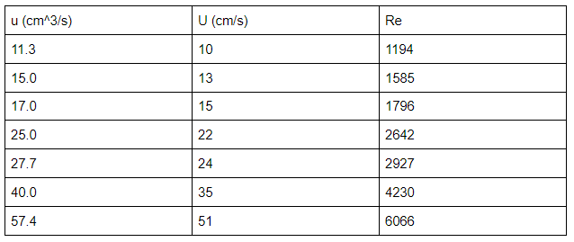

The text Fluid Mechanics by Kundu and Cohen indicates that laminar flow is characterized by a Reynolds number approximately less than ~3000. We further consider a reynolds number less than ~2000 to be laminar, and greater than ~4000 to be turbulent. With the range between the two to be a transition phase where different parts of the flow behave differently. We visually confirmed these results throughout the experiment.

- https://www.youtube.com/watch?v=r6IObTDFsIc&ab_channel=Physics426LaminarFlow
- https://www.youtube.com/watch?v=VAq6bmSMKPA&ab_channel=Physics426LaminarFlow
- https://www.youtube.com/watch?v=bBG9T_-wa0c&ab_channel=Physics426LaminarFlow

Laminar Flow: Reynolds Number < 2000

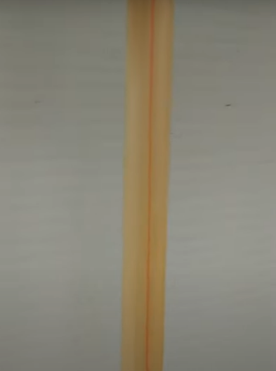

Laminar to Turbulent Transition: 2000 < Reynolds Number < 4000

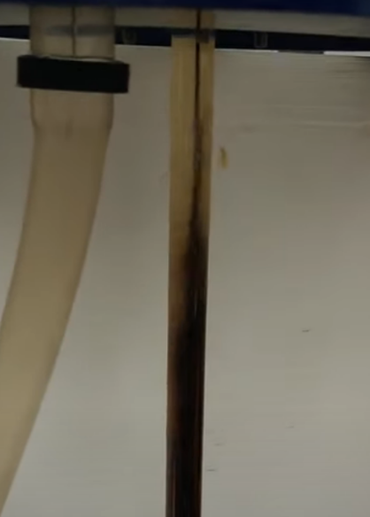

Turbulent Flow: Reynolds Number > 4000

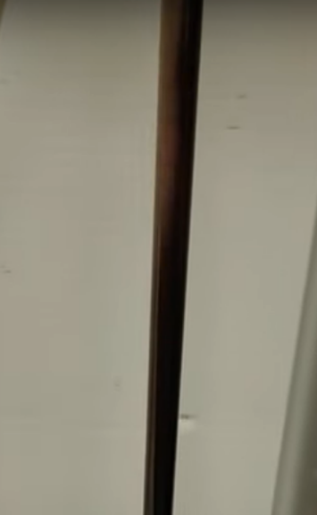

### Couette Cell

The Couette cell is composed of two aligned cylinders, an inner cylinder which is free to rotate, and a static outer cylinder. The space between the two cylinders can then be filled with fluid completing the apparatus. When the inner cylinder rotates, it pulls the fluid with it generating a flow, and, assuming that the rotation speed is not too high, the flow is laminar and flows purely in the angular direction. If the flow is laminar, because the fluid moves purely in the angular direction in layers with little to no inner mixing, then theoretically, if we rotate the cylinder a certain number of times the flow can be reversed by rotating the opposite direction at a similar speed, and the original state of the fluid can be recovered.

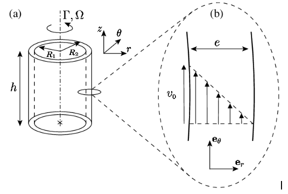

#### Procedure:

##### Water

The cell can be filled with any fluid, so to start the experiment is attempted with water. The space between the two cylinders is filled with water. Next dye is injected into the fluid and we attempt to rotate the inner cylinder. Due to the high diffusivity of water, the die tends to spread out too fast, before a flow can be created and then reversed.

##### Corn Syrup

In the case that the water experiment does not work, the experiment is attempted with corn syrup, since it has much higher viscosity and lower diffusivity. The cell is filled with corn syrup. Dye is then mixed with a fair amount of corn syrup and then injected into the cell. The inner cylinder is rotated at a constant rate, and then rotated the opposite direction at a similar rate. The original dye configuration is mixed around the cylinder by the rotation, and is then returned to approximately the original state by rotating the opposite direction.

#### Results:

- https://youtu.be/5KagSMXxSzc
- https://youtu.be/6ImFD-Fk-vA
- https://youtu.be/LnN-U8RiYmA
- https://youtu.be/HD6jbt-mcDc

#### Discussion:

The experiment could not be completed with water (see video 1), the dye diffuses too quickly and, as can be seen above, the inner cell would have to be rotated fairly quickly to get a flow going before the dye spreads out too far, however rotating too quickly introduces turbulence and prevents laminar flow. Once the fluid was changed to corn syrup (see video 2) the experiment went much better than previously, although we did still struggle with issues in methodology and with the apparatus. The experiment was repeated a third time with an apparatus constructed at home (see videos 3 and 4). The original apparatus had an inner cylinder which was not fixed in any way, and it would rise off the bottom of the cell, or wobble unpredictably. In order to avoid this instability, the new apparatus fixed the inner cylinder with string under tension. It still has a slight tendency to wobble when rotated rapidly, but it is fixed in place much better and does not lift off of the bottom of the cell at all. The material of the cup used caused a certain amount of friction with the strings and created vibrations in the cup, so in order to remove these perturbations the strings and the stem of the cup were liberally greased. In the third attempt the ratio of dye to corn syrup mixture was altered, only a very small amount of dye was mixed with a larger amount of corn syrup to ensure that the dyed mixture would have a much more similar viscosity and buoyancy to the corn syrup in the cell. In the original experiment the dye was placed too close to the surface, and it spread out on top rapidly, so in the third attempt it was also injected at a depth as close as possible to midway between the bottom boundary and the surface. The results of these changes were extraordinary, and the third attempt at the experiment worked excellently. As can be seen in the last two videos, the dye mixes as the cylinder is rotated, and the mixing is then undone as the cylinder is rotated back. When rotated at higher speeds it is difficult to tell if the inner cylinder was rotated fast enough to create a turbulent flow, or if when rotated that vigorously the stability of the string apparatus breaks down enough that significant perturbations are introduced by unpredictable wobbles in the inner cylinder. Under either circumstance the perturbations distort the dye in the cell from it’s original configuration. If the experiment were repeated I would try to attach some sort of handle to the top of the inner cylinder so that it could be rotated continuously, that way the rotation speed would be easier to measure, and the Reynolds number could be calculated.

#### Hints:

1. Try fixing the inner cylinder in some way. If attempting a similar fix as in the videos, grease the strings well. There is a non-negligible amount of friction between the strings and the inner cylinder and if they are not properly greased then they will catch on the cup as it is rotated causing the cup to jerk slightly.
2. Mix only a very small amount of dye relative to the corn syrup. Most food coloring or dyes found in the lab are very pigmented; only a drop or two will be more than enough. If too much dye is used relative to the corn syrup, then your final mixture will not have the right buoyancy or viscosity.
3. Inject the dye-corn syrup mixture directly into the midpoint between the surface and bottom. We found that if too close to the top, especially if the mixture is too buoyant, the dye will slide around on top of the corn syrup mixture instead of properly integrating with the flow.
4. We did not calculate the Reynolds number for the experiment because we found it too difficult to measure the rotation speed, especially with a homemade apparatus which required a non uniform method for rotating it. However, if using the apparatus in the lab, the rotation speed could be calculated if the number of rotations X, the dimensions of the apparatus and the time taken for X rotations was measured. From there the flow speed and then Reynolds number could be calculated.

#### Balloon Fun

Just for fun, we also tried a short test with a balloon. Using tape to stabilize a section of a balloon filled with water, it was popped and the water was allowed to flow out. At a certain point the ratio of balloon opening and flow speed determined by the inner pressure, to the viscosity of the water reaches a relatively low Reynolds number. The flow becomes laminar, and due to the fluid flowing in separate layers with little mixing (and being held together by surface tension) the shape of the stream holds constant with little turbulence, and the flow appears to freeze for a short amount of time. The experiment does not have as much to do with the characterization or exploration of the properties of individual flows, but it is an enjoyable exercise and does offer a small amount of insight into the movement of fluid in a laminar flow. See approximately 0:11 - 0:14

- https://youtu.be/NrCEGI2Yjvo